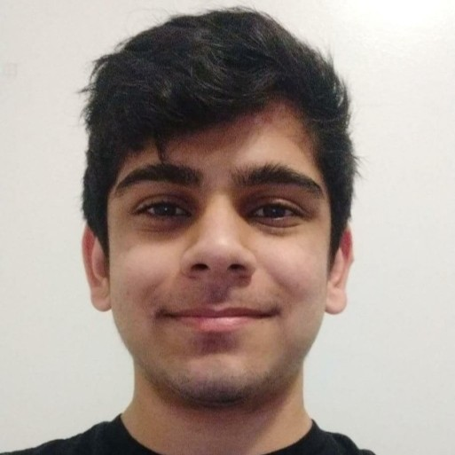

# Shoubhik Bhattacharya

## Bio

Shoubhik Bhattacharya is a graduating senior at the University of Toronto.He in completing a Bachelor of Arts Degree by majoring in Economics with a focus in Data Analytics while completing his minors in Statistics and Buddhist Psychology & Mental health. He has a strong passion for analytics by making sense out of data sets to produce meaningful and significant findings! This passion is fueled by his ability to code in programming languages such as Python, R, SQL and STATA. He has experience working in the educational sector as a Teaching Assistant at the University of Toronto and as a tutor in a Canadian Ed-Tech company, Paper. He has a passion for consulting, marketing and risk management and hopes to contribute to those industries in the near future.

## Education

**University of Toronto, St. George** | Toronto, ON

B.A. in Economics | September 2018 - May 2022

**Indus International School, Bangalore** | Bangalore, India

H.S Diploma and I.B Programme | August 2016 - May 2018

## Experience

**University of Toronto** | Teaching Assistant | September 2021 - December 2021

**Paper** | Professional Tutor | April 2020 - Present

**Canadian Undergraduates in Behavioural Science (CUBS)** | Research Assistant | October 2019 - March 2020

**AZ Research Partners** | Marketing and Finance Intern | May 2017 - July 2017